# BiodiversidadGJC

Juan Carlos García Estupiñán

# **Sobre mí**

Soy Biólogo, empecé mis estudios en la Universidad de Salamanca (USAL),pero terminé mis estudios en la Universidad de La Laguna (ULL) en Tenerife en 2022.

Tras realizar mi Trabajo de Fin de Grado en el análisis estadístico de tortugas marinas, me interesó mucho el uso de tecnologías para realizar investigación de fauna y flora mediante el análisis de datos y la creación de bases de datos, lo que me motivó a graduarme en un máster oficial de Bioinformática, impartido por la Universidad Internacional de Valencia (VIU).

Principalmente, mi experiencia hasta ahora ha estado relacionada con la gestión ambiental y la conservación de la biodiversidad. Comencé mi trayectoria como técnico superior biólogo en el Servicio Técnico de Medio Ambiente del Cabildo de Gran Canaria.

Esta experiencia, al implicar numerosas salidas de campo, me dio la oportunidad de crear esta web, que consiste en el desarrollo de una base de datos personal de especies, originalmente centrada en Gran Canaria, pero que he acabado ampliando a otras islas.

Posteriormente, he continuado mejorando este proyecto y ampliando mis conocimientos tras mi paso por entidades como Loro Parque Fundación y Gestión y Planeamiento Territorial y Medioambiental (GESPLAN), donde actualmente trabajo como Técnico Superior Biólogo de proyecto.

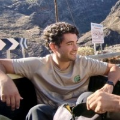

[**LinkedIn**](https://www.linkedin.com/in/jcgarciaestupi%C3%B1an/)

# **CONTACTA**

Pon tus datos en caso de que quieras contactar!

Nombre *

Apellidos *

E-mail *

Teléfono *

Mensaje *

*Última actualización el 22/11/2026*

Sitio [**desarrollado**](https://github.com/JuanCarlosBio/BiodiversidadGJC) por [**Juan Carlos García Estupiñán**](https://github.com/JuanCarlosBio/)

Puede ser interesante: [Inventario de especies de cada Espacio Natural Protegido](https://juancarlosbio.github.io/inventario_especies_enp/)

#### Contacta conmigo: ✉ GMAIL